# Práctica 2

### Clústering de datos

8. Utilizando un algoritmo de aprendizaje no supervisado, realizad un análisis de clústering con k-means para los datos del servidor.

```r
# Convertimos a string las IPs y las URLs porque sino dan error.
epa_http$`IPs` <- as.character(epa_http$`IPs`)
epa_http$`URL` <- as.character(epa_http$`URL`)

# Convertimos a factor los códigos de respuesta
epa_http$`Código de respuesta` <- as.factor(epa_http$`Código de respuesta`)

# Convertimos las columnas factor a distintas columnas numéricas que representan el valor de la variable factor de forma que pueda usarse en algoritmos que trabajan únicamente con valores numéricos.
epa_http_one_hot <- one_hot(as.data.table(epa_http), sparsifyNAs = TRUE)

# Añadimos nueva columna con el tamaño de la columna URL
epa_http_one_hot <- epa_http_one_hot %>%
  mutate(url_length = nchar(URL))

# Eliminamos columnas no númericas
epa_http_one_hot$URL <- NULL
epa_http_one_hot$IPs <- NULL
epa_http_one_hot$imagen <- NULL
epa_http_one_hot$Timestamp <- NULL
epa_http_one_hot$error <- NULL
epa_http_one_hot$tipo_error <- NULL

# Sustituimos los NAs por 0
epa_http_one_hot$Bytes [is.na (epa_http_one_hot$Bytes)] <- 0

# Aplicamos k-means con k = 3
k3 <- kmeans(epa_http_one_hot, centers = 3)

# Añadimos nueva columna con el tamaño de la columna URL
epa_http_one_hot$cluster3 <- as.factor(k3$cluster)

# Calculamos centroides
temp_centroides_3 <- k3$centers
centroides_3 <- temp_centroides_3[,(ncol(temp_centroides_3)-2):(ncol(temp_centroides_3)-1)]

# Aplicamos k-means con k = 4
k4 <- kmeans(epa_http_one_hot, centers = 4)

# Calculamos centroides
temp_centroides_4 <- k4$centers
centroides_4 <- temp_centroides_4[,(ncol(temp_centroides_4)-2):(ncol(temp_centroides_4)-1)]
```

9. Representad visualmente en gráficos de tipo scatter plot el resultado de vuestros clústering y interpretad el resultado obtenido

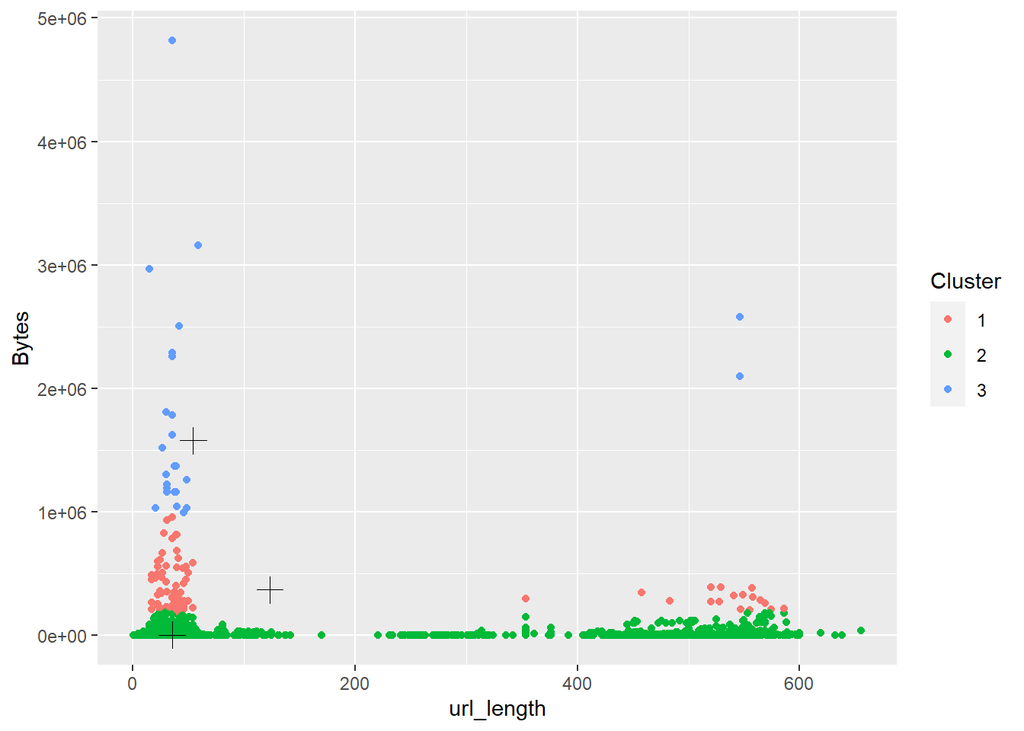

```r
# Generamos gráfico tipo scatter plot con el número de caracteres de la URL y los Bytes
ggplot(epa_http_one_hot, aes(x = url_length  , y = Bytes )) +
     geom_point(aes(color = as.factor(k3$cluster))) +
     geom_point(data = as.data.frame(k3$centers), aes(x = url_length , y = Bytes ), color = "black", size = 4, shape = 3) +
     labs(color = "Cluster")
```

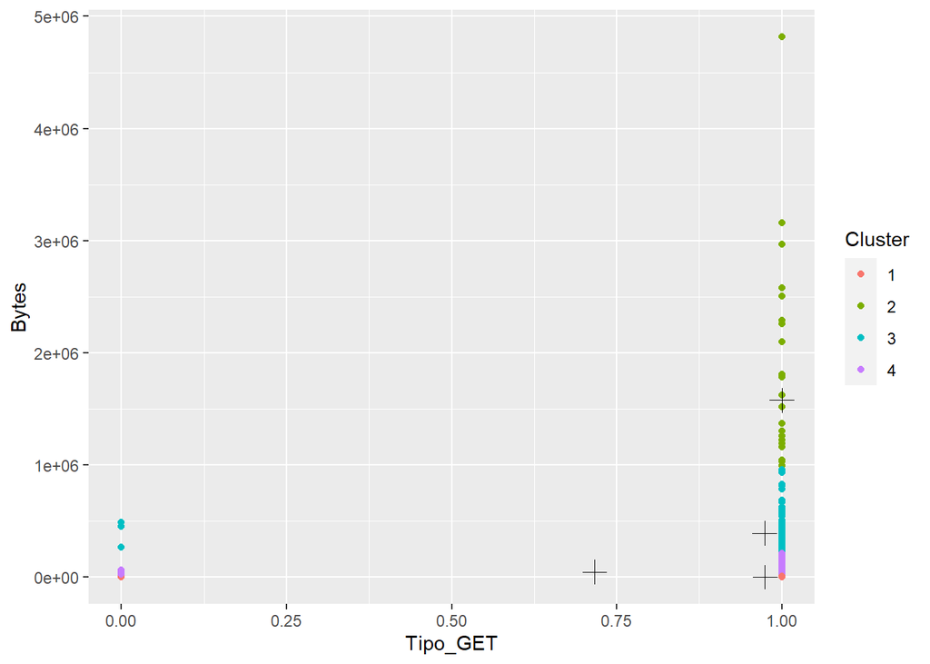

```r
# Generamos gráfico tipo scatter plot con las peticiones tipo GET y los Bytes
ggplot(epa_http_one_hot, aes(x = Tipo_GET , y = Bytes )) +
     geom_point(aes(color = as.factor(k4$cluster))) +
     geom_point(data = as.data.frame(k4$centers), aes(x = Tipo_GET, y = Bytes ), color = "black", size = 4, shape = 3) +
     labs(color = "Cluster")
```

En el primer gráfico, nos aporta información de que la mayor cantidad de URLs recolectadas son de longitud corta y hacen al servidor web transferir poca cantidad de bytes. Según se aprecia en los datos recolectados, es usual que los bytes transferidos no ocupan un gran tamaño tanto en URLs cortas como en las URLS largas

En el segundo gráfico, se evidencia que la mayoria de peticiones GET son las que hacen transferir al servidor una mayor cantidad de datos (bytes), y es muy poco usual que el resto de peticiones (HEAD y POST) transfieran gran cantidad de datos.